# Example Exposure Outcome Project

Hongxu Wang

14 January 2023

This project aims at introducing common analysis methods used in our lab.

# 1. Data Description

## Data Overview

**The example data is from TeenLabs. It include 19 variables**

**1) 1 id variable: deidentified ID**

**2) 5 covariates: race, smoke, age, sex and parents’ income.**

**4) 6 untargeted plasma pfas. pfda, pfhxs, pfhps, pfna, pfoa and pfos.**

**All variables in this example dataset are from baseline**

## Data Processing

**This part introduced methods to categorize continuous variables to binary, tertiled, quantiled, etc. variables.**

```r
## Define variables----

# plasma pfas
plasma_pfas <- colnames(data)[grepl("imputed",colnames(data))]
## or
# plasma_pfas <- c("pfda_untargeted_plasma_0_imputed",
#                  "pf_hx_s_untargeted_plasma_0_imputed",
#                  "pf_hp_s_untargeted_plasma_0_imputed",
#                  "pfna_untargeted_plasma_0_imputed",
#                  "pfoa_untargeted_plasma_0_imputed",
#                  "pfos_untargeted_plasma_0_imputed")

# Example1-----
## Step 1. Adding the categorical exposures into the data set----
data <- data %>%
  mutate_at(.vars = vars(all_of(plasma_pfas)),
            .funs = list(tertile = ~ntile(.,  3),
                         median = ~if_else(. > median(., na.rm = TRUE),
                                           2,
                                           1),
                         quantile = ~as.integer(cut(., quantile(., c(0, 1/4,1/2,3/4,1),
                                                                na.rm = TRUE))),
                         quintile = ~as.integer(cut(., quantile(., c(0, 1/5,2/5,3/5,4/5,1),
                                                                na.rm = TRUE))),
                         sextile = ~as.integer(cut(., quantile(., c(0, 1/6,2/6,3/6,4/6,5/6,1),
                                                               na.rm = TRUE))),
                         septile = ~as.integer(cut(., quantile(., c(0, 1/7,2/7,3/7,4/7,5/7,6/7,1),
                                                               na.rm = TRUE))),
                         octile = ~as.integer(cut(., quantile(., c(0, 1/8,2/8,3/8,4/8,5/8,6/8,7/8,1),
                                                              na.rm = TRUE)))
            ))

# extracted the related column names and stored into a variable-----
pfas_names_categorical <- colnames(data)[
  grepl("median|tertile|quantile|quintile|sextile|septile|octile",
        colnames(data))]

## Step 2. Getting the intervals for each categorized data-----
data_interval <- data %>%
  mutate_at(.vars = vars(all_of(plasma_pfas)),
            .funs = list(tertile = ~cut(., quantile(., c(0, 1/3, 2/3, 1),
                                                    na.rm = TRUE)),
                         median = ~cut(., quantile(., c(0, 1/2, 1),
                                                   na.rm = TRUE)),
                         quantile = ~cut(., quantile(., c(0, 1/4,1/2,3/4,1),
                                                     na.rm = TRUE)),
                         quintile = ~cut(., quantile(., c(0, 1/5,2/5,3/5,4/5,1),
                                                     na.rm = TRUE)),
                         sextile = ~ cut(., quantile(., c(0, 1/6,2/6,3/6,4/6,5/6,1),
                                                     na.rm = TRUE)),
                         septile = ~ cut(., quantile(., c(0, 1/7,2/7,3/7,4/7,5/7,6/7,1),
                                                     na.rm = TRUE)),
                         octile  = ~ cut(., quantile(., c(0, 1/8,2/8,3/8,4/8,5/8,6/8,7/8,1),
                                                     na.rm = TRUE))
            ))

## Step 3. saving the intervals information to a file-----
interval <- data_interval %>%
  dplyr::select(all_of(pfas_names_categorical)) %>%
  map(.,table) %>%
  map(.,as.data.frame) %>%
  bind_rows(.id = "pfas") %>%
  dplyr::rename(interval = Var1,
                count = Freq)

n <- length(plasma_pfas)

num <- c(rep(c(1,2,3),n),rep(c(1,2),n),
         rep(c(1,2,3,4),n), rep(c(1,2,3,4,5),n),
         rep(c(1,2,3,4,5,6),n), rep(c(1,2,3,4,5,6,7),n),
         rep(c(1,2,3,4,5,6,7,8),n))

interval_df<- interval %>% mutate(level = num,
                                  pfas = str_c(pfas, level, ""))

write_csv(interval_df,fs::path(dir_report,"Categorical_plasma_pfas_intervals.csv"))

# Example 2. Adding categorical outcome to the data-----
## creating new dichotomous ALT variable
data <- data %>% tidylog::drop_na(alt_0) %>%
  mutate(alt_di_0 = case_when(
    alt_0 > 25.8 & sex =="male" ~ 'high',
    alt_0 > 22.1 & sex =="female" ~ 'high',
    TRUE ~ 'low'
  ),
  alt_di_0 = factor(alt_di_0, levels = c("low", "high"),
                    ordered = TRUE)
  )
```

# 2. Descriptive Statistics

## Descriptive Statistics Overview

**This script introduce three methods of obtaining descriptive statistics**

## Method 1. summarytools::view(summarytools::dfSummary())

```r
## Step1. Define variables----
# covariates
covars <- c("race_binary",
            "smoke_0",
            "age_0",
            "sex",
            "parents_income_0")

# categorical outcomes(two categories or more)
cat_outcomes <- c("nafld_nash_mul_0", "nafld_di_0","steatgrd_mul_0", "bhepa_0",
                   "dyslipid_di_0")

# continuous outcomes
cont_outcomes <- c("alt_0", "ast_0")

# plasma pfas
plasma_pfas <- colnames(data)[grepl("imputed",colnames(data))]
## or
# plasma_pfas <- c("pfda_untargeted_plasma_0_imputed",
#                  "pf_hx_s_untargeted_plasma_0_imputed",
#                  "pf_hp_s_untargeted_plasma_0_imputed",
#                  "pfna_untargeted_plasma_0_imputed",
#                  "pfoa_untargeted_plasma_0_imputed",
#                  "pfos_untargeted_plasma_0_imputed")

# Step 2. Descriptive statistics-----
## Method 1. summarytools::view(summarytools::dfSummary())
summarytools::view(summarytools::dfSummary(data,
                   style = 'grid',
                   max.distinct.values = 10,
                   plain.ascii =   FALSE,
                   valid.col = FALSE,
                   headings = FALSE), method = "render")
```

| **No** | **Variable** | **Stats / Values** | **Freqs (% of Valid)** | **Graph** | **Missing** |
| --- | --- | --- | --- | --- | --- |
| 1 | key [character] | 1. 7002 2. 7004 3. 7006 4. 7008 5. 7018 6. 7029 7. 7039 8. 7042 9. 7044 10. 7050 [ 210 others ] | 1 ( 0.5% ) 1 ( 0.5% ) 1 ( 0.5% ) 1 ( 0.5% ) 1 ( 0.5% ) 1 ( 0.5% ) 1 ( 0.5% ) 1 ( 0.5% ) 1 ( 0.5% ) 1 ( 0.5% ) 210 ( 95.5% ) |  | 0 (0.0%) |
| 2 | race_binary [factor] | 1. Others 2. White or Caucasian | 64 ( 29.1% ) 156 ( 70.9% ) |  | 0 (0.0%) |
| 3 | smoke_0 [factor] | 1. Never smoked 2. Current 3. Former | 180 ( 93.8% ) 5 ( 2.6% ) 7 ( 3.6% ) |  | 28 (12.7%) |
| 4 | age_0 [numeric] | Mean (sd) : 17.1 (1.5) min ≤ med ≤ max: 13.2 ≤ 17.2 ≤ 20 IQR (CV) : 2.3 (0.1) | 216 distinct values |  | 0 (0.0%) |
| 5 | sex [factor] | 1. male 2. female | 54 ( 24.5% ) 166 ( 75.5% ) |  | 0 (0.0%) |
| 6 | parents_income_0 [character] | 1. 25000-74999 2. 75000 or more 3. less than 25000 | 71 ( 39.0% ) 43 ( 23.6% ) 68 ( 37.4% ) |  | 38 (17.3%) |
| 7 | nafld_nash_mul_0 [ordered, factor] | 1. No NAFLD 2. NAFLD not NASH 3. NASH | 63 ( 41.4% ) 54 ( 35.5% ) 35 ( 23.0% ) |  | 68 (30.9%) |
| 8 | nafld_di_0 [ordered, factor] | 1. No NAFLD 2. NAFLD | 63 ( 41.4% ) 89 ( 58.6% ) |  | 68 (30.9%) |
| 9 | steatgrd_mul_0 [ordered, factor] | 1. 0% and <5% 2. 5-33% 3. 33-67% and >67% | 66 ( 43.4% ) 56 ( 36.8% ) 30 ( 19.7% ) |  | 68 (30.9%) |
| 10 | bhepa_0 [ordered, factor] | 1. None 2. Fedata_w, less characteri 3. Many, prominent | 124 ( 81.6% ) 21 ( 13.8% ) 7 ( 4.6% ) |  | 68 (30.9%) |
| 11 | dyslipid_di_0 [ordered, factor] | 1. Not Present 2. Present | 104 ( 54.5% ) 87 ( 45.5% ) |  | 29 (13.2%) |
| 12 | alt_0 [numeric] | Mean (sd) : 30.8 (20.5) min ≤ med ≤ max: 6 ≤ 25 ≤ 132 IQR (CV) : 18.2 (0.7) | 58 distinct values |  | 52 (23.6%) |
| 13 | ast_0 [numeric] | Mean (sd) : 31.3 (15.1) min ≤ med ≤ max: 11 ≤ 28 ≤ 110 IQR (CV) : 17 (0.5) | 49 distinct values |  | 52 (23.6%) |
| 14 | pfda_untargeted_plasma_0_imputed [numeric] | Mean (sd) : 0.6 (0.1) min ≤ med ≤ max: 0 ≤ 0.5 ≤ 1.6 IQR (CV) : 0.1 (0.3) | 186 distinct values |  | 34 (15.5%) |
| 15 | pf_hx_s_untargeted_plasma_0_imputed [numeric] | Mean (sd) : 2.3 (2.3) min ≤ med ≤ max: 0.3 ≤ 1.5 ≤ 14.9 IQR (CV) : 1.5 (1) | 186 distinct values |  | 34 (15.5%) |
| 16 | pf_hp_s_untargeted_plasma_0_imputed [numeric] | Mean (sd) : 0.2 (0.1) min ≤ med ≤ max: 0.1 ≤ 0.2 ≤ 0.9 IQR (CV) : 0.1 (0.5) | 186 distinct values |  | 34 (15.5%) |
| 17 | pfna_untargeted_plasma_0_imputed [numeric] | Mean (sd) : 0.9 (0.4) min ≤ med ≤ max: 0.3 ≤ 0.8 ≤ 2.8 IQR (CV) : 0.4 (0.4) | 186 distinct values |  | 34 (15.5%) |
| 18 | pfoa_untargeted_plasma_0_imputed [numeric] | Mean (sd) : 3.9 (3) min ≤ med ≤ max: 0.8 ≤ 3.3 ≤ 23.1 IQR (CV) : 2 (0.8) | 186 distinct values |  | 34 (15.5%) |
| 19 | pfos_untargeted_plasma_0_imputed [numeric] | Mean (sd) : 6.2 (3.1) min ≤ med ≤ max: 1.5 ≤ 5.7 ≤ 19.1 IQR (CV) : 3.5 (0.5) | 186 distinct values |  | 34 (15.5%) |

Generated by summarytools 1.0.1 ([R](https://www.r-project.org/) version 4.2.0)  
2023-01-14

## Method 2. table1::table1()

```r
## Method 2. table1::table1()
stats <- table1(~., data = data %>% dplyr::select(-key))

stats
```

|  | Overall (N=220) |
| --- | --- |
| race_binary |  |
| Others | 64 (29.1%) |
| White or Caucasian | 156 (70.9%) |
| smoke_0 |  |
| Never smoked | 180 (81.8%) |
| Current | 5 (2.3%) |
| Former | 7 (3.2%) |
| Missing | 28 (12.7%) |
| age_0 |  |
| Mean (SD) | 17.1 (1.53) |
| Median [Min, Max] | 17.2 [13.2, 20.0] |
| sex |  |
| male | 54 (24.5%) |
| female | 166 (75.5%) |
| parents_income_0 |  |
| 25000-74999 | 71 (32.3%) |
| 75000 or more | 43 (19.5%) |
| less than 25000 | 68 (30.9%) |
| Missing | 38 (17.3%) |
| nafld_nash_mul_0 |  |
| No NAFLD | 63 (28.6%) |
| NAFLD not NASH | 54 (24.5%) |
| NASH | 35 (15.9%) |
| Missing | 68 (30.9%) |
| nafld_di_0 |  |
| No NAFLD | 63 (28.6%) |
| NAFLD | 89 (40.5%) |
| Missing | 68 (30.9%) |
| steatgrd_mul_0 |  |
| 0% and <5% | 66 (30.0%) |
| 5-33% | 56 (25.5%) |
| 33-67% and >67% | 30 (13.6%) |
| Missing | 68 (30.9%) |
| bhepa_0 |  |
| None | 124 (56.4%) |
| Fedata_w, less characteristic | 21 (9.5%) |
| Many, prominent | 7 (3.2%) |
| Missing | 68 (30.9%) |
| dyslipid_di_0 |  |
| Not Present | 104 (47.3%) |
| Present | 87 (39.5%) |
| Missing | 29 (13.2%) |
| alt_0 |  |
| Mean (SD) | 30.8 (20.5) |
| Median [Min, Max] | 25.0 [6.00, 132] |
| Missing | 52 (23.6%) |
| ast_0 |  |
| Mean (SD) | 31.3 (15.1) |
| Median [Min, Max] | 28.0 [11.0, 110] |
| Missing | 52 (23.6%) |
| pfda_untargeted_plasma_0_imputed |  |
| Mean (SD) | 0.563 (0.143) |
| Median [Min, Max] | 0.547 [0.00500, 1.63] |
| Missing | 34 (15.5%) |
| pf_hx_s_untargeted_plasma_0_imputed |  |
| Mean (SD) | 2.28 (2.35) |
| Median [Min, Max] | 1.51 [0.273, 14.9] |
| Missing | 34 (15.5%) |
| pf_hp_s_untargeted_plasma_0_imputed |  |
| Mean (SD) | 0.240 (0.122) |
| Median [Min, Max] | 0.212 [0.0521, 0.897] |
| Missing | 34 (15.5%) |
| pfna_untargeted_plasma_0_imputed |  |
| Mean (SD) | 0.857 (0.378) |
| Median [Min, Max] | 0.764 [0.304, 2.77] |
| Missing | 34 (15.5%) |
| pfoa_untargeted_plasma_0_imputed |  |
| Mean (SD) | 3.86 (3.00) |
| Median [Min, Max] | 3.31 [0.763, 23.1] |
| Missing | 34 (15.5%) |
| pfos_untargeted_plasma_0_imputed |  |
| Mean (SD) | 6.17 (3.08) |
| Median [Min, Max] | 5.65 [1.48, 19.1] |
| Missing | 34 (15.5%) |

## Method 3. group_by() –> summarise()

```r
## Method 3. pivot_longer --> group_by() --> summarise()
## Take pfas as example

# long format data for plasma pfas
data_l <- data %>%
  pivot_longer(
  names_to = "variables",
  values_to = "value",
  cols = c(all_of(plasma_pfas)))

# descriptive statistics
stats <- data_l %>%
  drop_na(value) %>%
  group_by(variables) %>%
  dplyr::summarise(
    geometric_mean = fungm(value),
    percentile_50 = qntle_fxn(value, .50),
    percentile_75 = qntle_fxn(value, .75),
    percentile_90 = qntle_fxn(value, .9)) %>%
  ungroup()

# Rename columns
stats_summary <- stats %>%
  dplyr::rename(
    "PFAS" = variables,
    "Geometric Mean [95% CI]" = geometric_mean,
    "50th percentile" = percentile_50,
    "75th percentile" = percentile_75,
    "90th percentile" = percentile_90)
# save result
# write_csv(stats_summary, fs::path(dir_report,
#                                   "1_0_descriptive_stats.csv"))
stats_summary
```

| PFAS | Geometric Mean [95% CI] | 50th percentile | 75th percentile | 90th percentile |
| --- | --- | --- | --- | --- |
| pf_hp_s_untargeted_plasma_0_imputed | 0.215 [0.201, 0.23] | 0.212 | 0.292 | 0.396 |
| pf_hx_s_untargeted_plasma_0_imputed | 1.66 [1.49, 1.85] | 1.51 | 2.46 | 4.24 |
| pfda_untargeted_plasma_0_imputed | 0.541 [0.511, 0.572] | 0.547 | 0.597 | 0.669 |
| pfna_untargeted_plasma_0_imputed | 0.793 [0.75, 0.838] | 0.764 | 0.992 | 1.22 |
| pfoa_untargeted_plasma_0_imputed | 3.24 [2.99, 3.51] | 3.31 | 4.28 | 5.52 |
| pfos_untargeted_plasma_0_imputed | 5.49 [5.12, 5.9] | 5.65 | 7.49 | 10.2 |

# 3. Correlation Plot

## Correlation plot

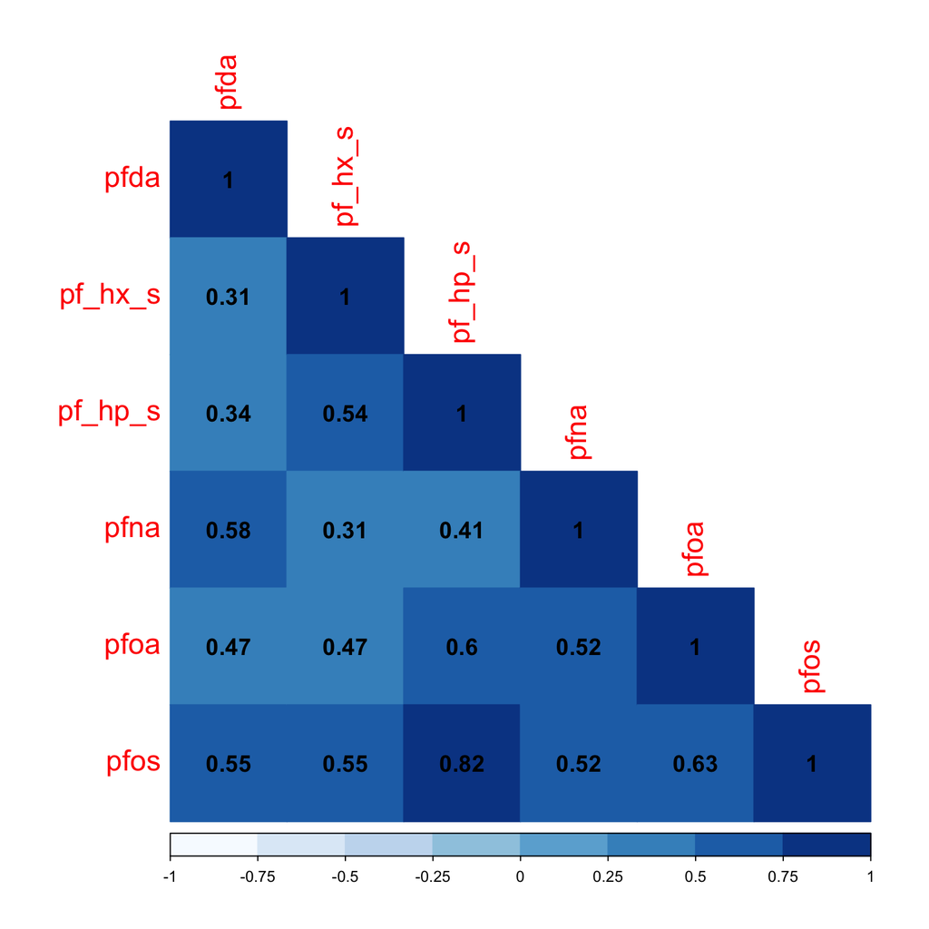

```r
# covariates
covars <- c("race_binary",
            "smoke_0",
            "age_0",
            "sex",
            "parents_income_0")

# categorical outcomes(two categories or more)
cat_outcomes <- c("nafld_di_0","dyslipid_di_0","nafld_nash_mul_0","steatgrd_mul_0", "bhepa_0")

# continuous outcomes
cont_outcomes <- c("alt_0", "ast_0")

# clean the name of the columns
data1<- data %>%
  rename_all(~str_replace_all(., "_untargeted_plasma_0_imputed", ""))

# extract plasma pfas name
plasma_pfas1 <- setdiff(colnames(data1), c(covars, cat_outcomes, cont_outcomes , "key"))

# exposure data

corr <- cor(data1 %>% dplyr::select(all_of(plasma_pfas1)), use = "complete.obs", method = "spearman") # if data contains na can use = "complete.obs" can handle it.

corrplot(corr, type="lower",
         col=brewer.pal(n=8, name="Blues"),
         title = "",
         method = "color",
         addCoef.col = "black",
         tl.cex=1.5, number.cex=1.2)
```

# 4. Regression Methods

**This analysis relies on the broom and purrr packages in R and you can find more information here https://cran.r-project.org/web/packages/broom/vignettes/broom_and_dplyr.html, especially how the nest/unnest functions in tidyr and the map function in purrr work.**

## Regression Methods

**This part gives example code of building logistic regression, linear regression, ordinal logistic regression and multinomial logistic regression together with method of obtaining coefficient plots**

**Continuous outcomes were group mean centered, exposures were log2 transformed**

## Model 1. Binary Logistic Regression

**binary outcome ~ plasma pfas + covars**

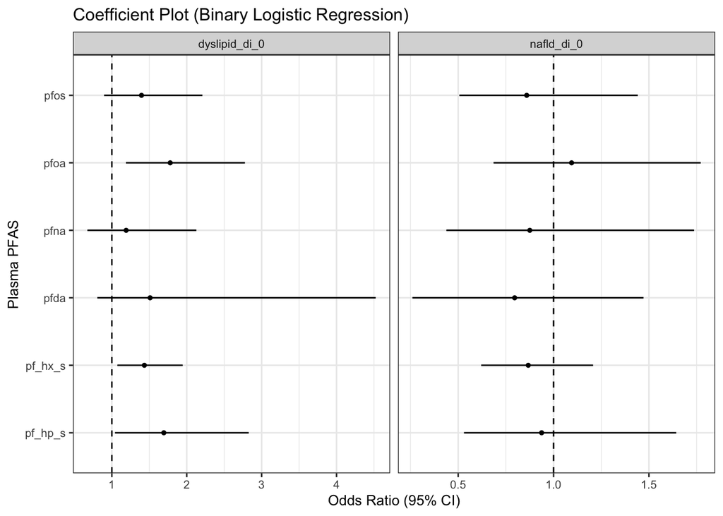

```r
## Define variables----
# covariates
covars <- c("race_binary",
            "smoke_0",
            "age_0",
            "sex",
            "parents_income_0")

# categorical outcomes(two categories or more)
cat_outcomes_di <- c("nafld_di_0","dyslipid_di_0")

cat_outcomes_mul <- c("nafld_nash_mul_0","steatgrd_mul_0")

# continuous outcomes
cont_outcomes <- c("alt_0", "ast_0")

# plasma pfas
plasma_pfas <- colnames(data)[grepl("imputed",colnames(data))]
## or
# plasma_pfas <- c("pfda_untargeted_plasma_0_imputed",
#                  "pf_hx_s_untargeted_plasma_0_imputed",
#                  "pf_hp_s_untargeted_plasma_0_imputed",
#                  "pfna_untargeted_plasma_0_imputed",
#                  "pfoa_untargeted_plasma_0_imputed",
#                  "pfos_untargeted_plasma_0_imputed")

## Model1: Logistic regression: cat_outcomes_di ~ plasma pfas + covars----
# log2 transfored for the exposures/plasma pfas

### Create regression model formula----
eo_combinations1 <- list(
  x = plasma_pfas,
  y = cat_outcomes_di) %>%
  cross_df()

models1 <- eo_combinations1 %>%
  mutate(covars = str_c(covars, collapse = "+"),
    formula = str_c(y,"~","log2(", x,")", "+", covars))

### Run logistic regression----
models1$output <- map(models1$formula,
                     ~glm(as.formula(.),
                          data = data,
                          na.action = na.exclude,
                          family = "binomial") %>%
                       tidy(., conf.int = TRUE)
  )

### Create final dataframe of all results----
mod_output_df1 <- models1 %>%
  unnest(output) %>%
  mutate(odds_ratio = exp(estimate),
         exp_conf_high = exp(conf.high),
         exp_conf_low = exp(conf.low)) %>%
  separate(x,
           into = c("pfas", NA),
           sep = "_targeted|_untargeted",
           remove = FALSE) %>%
  clean_names()

### Coefficient plot-----
mod_output_df1[grep("log2", mod_output_df1$term),] %>%
    ggplot(aes(x = pfas,y = odds_ratio)) +
    geom_point(size = 1) +
    coord_flip() +
    geom_errorbar(aes(ymin = exp_conf_low,
                      ymax = exp_conf_high),
                  width = 0) +
    geom_hline(yintercept = 1, linetype = 2) +
    ylab("Odds Ratio (95% CI)") +
    xlab("Plasma PFAS") +
    ggtitle("Coefficient Plot (Binary Logistic Regression)") +
    theme_bw() +
    theme(text = element_text(size = 10))+
    theme(legend.title = element_blank()) +
    coord_flip() +
    facet_wrap(.~ y,scales = "free_x")
```

```r
### Saving coefficient plots----
# ggsave(fs::path(dir_figure,"1_coefficient_plot.png"),
#        width = 7, height = 3, dpi = 300)
```

## Model 2. Ordinal Logistic Regression

**ordered outcome ~ plasma pfas + covars**

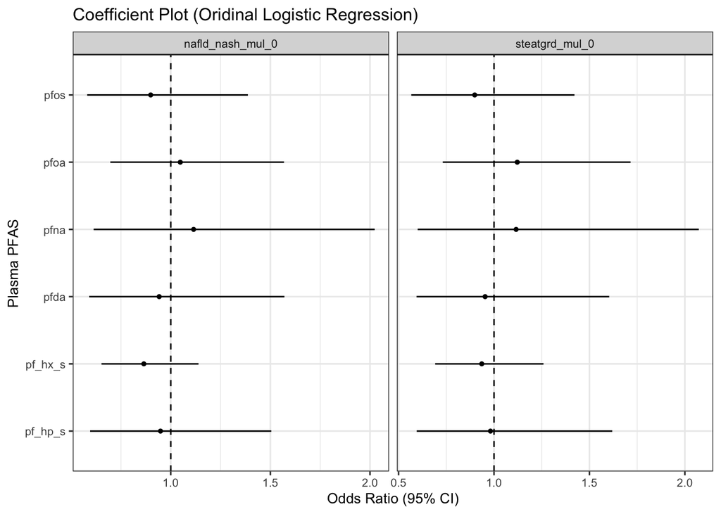

```r
### Create regression model formula----
eo_combinations2 <- list(
  x = plasma_pfas,
  y = cat_outcomes_mul) %>%
  cross_df()

models2 <- eo_combinations2 %>%
  mutate(covars = str_c(covars, collapse = "+"),
         formula = str_c(y,"~","log2(", x,")", "+", covars))

### Run ordinal logistic regression----
models2$output <- map(models2$formula,
                     ~polr(as.formula(.),
                          data = data,
                          na.action = na.exclude,
                          Hess = TRUE) %>%
                       tidy(., conf.int = TRUE))

### Create final data frame of all results----
mod_output_df2 <- models2 %>%
  unnest(output) %>%
  mutate(odds_ratio = exp(estimate),
         exp_conf_high = exp(conf.high),
         exp_conf_low = exp(conf.low)) %>%
    separate(x,
           into = c("pfas", NA),
           sep = "_targeted|_untargeted",
           remove = FALSE) %>%
  clean_names()

### Coefficient plot-----
mod_output_df2[grep("log2", mod_output_df2$term),] %>%
    ggplot(aes(x = pfas,y = odds_ratio)) +
    geom_point(size = 1) +
    coord_flip() +
    geom_errorbar(aes(ymin = exp_conf_low,
                      ymax = exp_conf_high),
                  width = 0) +
    geom_hline(yintercept = 1, linetype = 2) +
    ylab("Odds Ratio (95% CI)") +
    xlab("Plasma PFAS") +
    ggtitle("Coefficient Plot (Oridinal Logistic Regression)") +
    coord_flip() +
    facet_wrap(.~ y,scales = "free_x")+
    theme_bw() +
    theme(text = element_text(size = 10))+
    theme(legend.title = element_blank())
```

```r
### Saving coefficient plots----
# ggsave(fs::path(dir_figure,"1_coefficient_plot.png"),
#        width = 7, height = 3, dpi = 300)
```

## Model 3. Linear regression

**continuous outcomes ~ plasma pfas + covars**

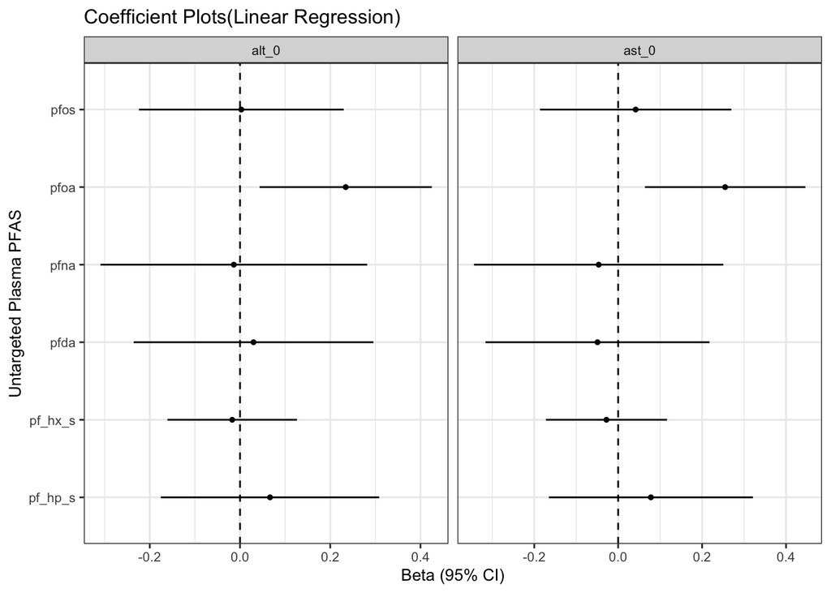

```r
### Create regression model formula----
eo_combinations3 <- list(
  x = plasma_pfas,
  y = cont_outcomes) %>%
  cross_df()

models3 <- eo_combinations3 %>%
  mutate(covars = str_c(covars, collapse = "+"),
    formula = str_c("scale(", y,")","~","log2(", x,")", "+", covars))

### Run linear regression----
models3$output <- map(models3$formula,
                      ~lm(as.formula(.),
                            data = data,
                            na.action = na.exclude) %>%
                        tidy(., conf.int = TRUE)
)

### Create final data frame of all results----
mod_output_df3 <- models3 %>%
  unnest(output) %>%
  separate(x,
           into = c("pfas", NA),
           sep = "_targeted|_untargeted",
           remove = FALSE) %>%
  clean_names()
### coefficient plots -----
mod_output_df3[grep("log2", mod_output_df3$term),] %>%
  ggplot(aes(x = pfas,y = estimate)) +
  geom_point(size = 1) +
  coord_flip()+
  geom_errorbar(aes(ymin = conf_low,
                    ymax = conf_high),
                width = 0) +
  geom_hline(yintercept = 0, linetype = 2) +
  ylab("Beta (95% CI)") +
  xlab("Untargeted Plasma PFAS") +
  ggtitle("Coefficient Plots(Linear Regression)")+
  theme_bw() +
  theme(text = element_text(size = 10))+
  theme(legend.title = element_blank()) +
  coord_flip() +
  facet_wrap(.~ y,scales = "free_x")
```

```r
### saving coefficient plots-----
# ggsave(fs::path(dir_figure,"1_coefficient_plot.png"),
#        width = 7, height = 3, dpi = 300)
```

## Model 4. Multinomial Logistic regression

**multi-level categorical outcomes ~ plasma pfas + covars**

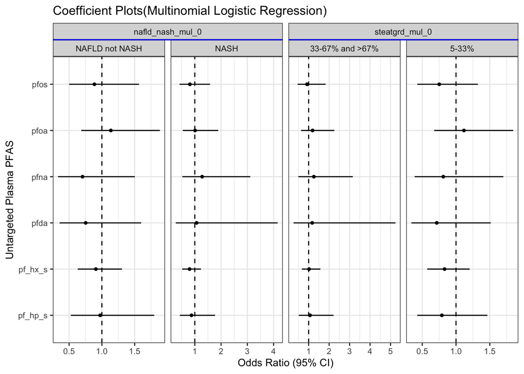

```r
### Create regression model formula----
eo_combinations4 <- list(
  x = plasma_pfas,
  y = cat_outcomes_mul) %>%
  cross_df()

models4 <- eo_combinations4 %>%
  mutate(covars = str_c(covars, collapse = "+"),
         formula = str_c(y,"~","log2(", x,")", "+", covars))

### Run multinomial logistic regression----
models4$output <- map(models4$formula,
                      ~nnet::multinom(as.formula(.),
                                      data = data,
                                      na.action = na.exclude, trace = FALSE) %>%
                        tidy(., conf.int = TRUE))

### Create final data frame of all results----
mod_output_df4 <- models4 %>%
  unnest(output) %>%
  mutate(odds_ratio = exp(estimate),
         exp_conf_high = exp(conf.high),
         exp_conf_low = exp(conf.low)) %>%
  separate(x,
           into = c("pfas", NA),
           sep = "_targeted|_untargeted",
           remove = FALSE) %>%
  clean_names()

### Create Coefficient Plots-----
mod_output_df4[grep("log2", mod_output_df4$term),] %>%
  ggplot(aes(x = pfas,y = odds_ratio)) +
  geom_point(size = 1) +
  coord_flip()+
  geom_errorbar(aes(ymin = exp_conf_low,
                    ymax = exp_conf_high),
                width = 0) +
  geom_hline(yintercept = 1, linetype = 2) +
  ylab("Odds Ratio (95% CI)") +
  xlab("Untargeted Plasma PFAS") +
  ggtitle("Coefficient Plots(Multinomial Logistic Regression)") +
  theme_bw() +
  theme(text = element_text(size = 10))+
  theme(legend.title = element_blank()) +
  coord_flip() +
  facet_nested_wrap(. ~ y + y_level,
                    scales = "free_x",
                    nest_line = element_line(colour = "blue"),
                    ncol = 4)
```

```r
### Saving coefficient plots----
# ggsave(fs::path(dir_figure,"1_coefficient_plot.png"),
#        width = 7, height = 3, dpi = 300)
```

## Regression report

**This part includes the method to combine different regression results into one report**

```r
mod_output_df <- mod_output_df1 %>%
  mutate(method = "logistic regression") %>%
  bind_rows(mod_output_df2 %>%
              mutate(method = "ordinal logistic regression")%>%
              dplyr::select(-coef_type)) %>%
  bind_rows(mod_output_df3 %>%
              mutate(method = "linear regression")) %>%
  bind_rows(mod_output_df4 %>%
              mutate(method = "multinomial logsitic regression")) %>%
  dplyr::select(method, everything())

## Saving results----
# write_csv(mod_output_df,fs::path(dir_report,
#                                  "1_Regression Result.csv"))
mod_output_df
```

| method | x | pfas | y | covars | formula | term | estimate | std_error | statistic | p_value | conf_low | conf_high | odds_ratio | exp_conf_high | exp_conf_low | y_level |
| --- | --- | --- | --- | --- | --- | --- | --- | --- | --- | --- | --- | --- | --- | --- | --- | --- |
| logistic regression | pfda_untargeted_plasma_0_imputed | pfda | nafld_di_0 | race_binary+smoke_0+age_0+sex+parents_income_0 | nafld_di_0~log2(pfda_untargeted_plasma_0_imputed)+race_binary+smoke_0+age_0+sex+parents_income_0 | (Intercept) | -4.850709534 | 2.268744e+00 | -2.138059e+00 | 0.032511940 | -9.450692781 | -4.996709e-01 | 7.822825e-03 | 6.067303e-01 | 7.863507e-05 | NA |
| logistic regression | pfda_untargeted_plasma_0_imputed | pfda | nafld_di_0 | race_binary+smoke_0+age_0+sex+parents_income_0 | nafld_di_0~log2(pfda_untargeted_plasma_0_imputed)+race_binary+smoke_0+age_0+sex+parents_income_0 | log2(pfda_untargeted_plasma_0_imputed) | -0.228259861 | 3.728351e-01 | -6.122273e-01 | 0.540387369 | -1.347323643 | 3.864631e-01 | 7.959174e-01 | 1.471766e+00 | 2.599350e-01 | NA |
| logistic regression | pfda_untargeted_plasma_0_imputed | pfda | nafld_di_0 | race_binary+smoke_0+age_0+sex+parents_income_0 | nafld_di_0~log2(pfda_untargeted_plasma_0_imputed)+race_binary+smoke_0+age_0+sex+parents_income_0 | race_binaryWhite or Caucasian | 0.370161857 | 3.968099e-01 | 9.328443e-01 | 0.350900386 | -0.411300640 | 1.151664e+00 | 1.447969e+00 | 3.163452e+00 | 6.627876e-01 | NA |
| logistic regression | pfda_untargeted_plasma_0_imputed | pfda | nafld_di_0 | race_binary+smoke_0+age_0+sex+parents_income_0 | nafld_di_0~log2(pfda_untargeted_plasma_0_imputed)+race_binary+smoke_0+age_0+sex+parents_income_0 | smoke_0Current | -1.507038683 | 1.208255e+00 | -1.247285e+00 | 0.212292850 | -4.571400131 | 6.745361e-01 | 2.215651e-01 | 1.963122e+00 | 1.034347e-02 | NA |
| logistic regression | pfda_untargeted_plasma_0_imputed | pfda | nafld_di_0 | race_binary+smoke_0+age_0+sex+parents_income_0 | nafld_di_0~log2(pfda_untargeted_plasma_0_imputed)+race_binary+smoke_0+age_0+sex+parents_income_0 | smoke_0Former | -2.407050120 | 1.310746e+00 | -1.836397e+00 | 0.066299018 | -5.618718886 | -7.373489e-02 | 9.008063e-02 | 9.289179e-01 | 3.629288e-03 | NA |
| logistic regression | pfda_untargeted_plasma_0_imputed | pfda | nafld_di_0 | race_binary+smoke_0+age_0+sex+parents_income_0 | nafld_di_0~log2(pfda_untargeted_plasma_0_imputed)+race_binary+smoke_0+age_0+sex+parents_income_0 | age_0 | 0.291689355 | 1.286310e-01 | 2.267645e+00 | 0.023350848 | 0.045235649 | 5.525602e-01 | 1.338687e+00 | 1.737696e+00 | 1.046274e+00 | NA |
| logistic regression | pfda_untargeted_plasma_0_imputed | pfda | nafld_di_0 | race_binary+smoke_0+age_0+sex+parents_income_0 | nafld_di_0~log2(pfda_untargeted_plasma_0_imputed)+race_binary+smoke_0+age_0+sex+parents_income_0 | sexfemale | -0.409968417 | 4.373866e-01 | -9.373136e-01 | 0.348597276 | -1.295366242 | 4.317806e-01 | 6.636712e-01 | 1.539997e+00 | 2.737976e-01 | NA |
| logistic regression | pfda_untargeted_plasma_0_imputed | pfda | nafld_di_0 | race_binary+smoke_0+age_0+sex+parents_income_0 | nafld_di_0~log2(pfda_untargeted_plasma_0_imputed)+race_binary+smoke_0+age_0+sex+parents_income_0 | parents_income_075000 or more | 0.777109578 | 5.456955e-01 | 1.424072e+00 | 0.154425717 | -0.264696105 | 1.894208e+00 | 2.175176e+00 | 6.647282e+00 | 7.674391e-01 | NA |
| logistic regression | pfda_untargeted_plasma_0_imputed | pfda | nafld_di_0 | race_binary+smoke_0+age_0+sex+parents_income_0 | nafld_di_0~log2(pfda_untargeted_plasma_0_imputed)+race_binary+smoke_0+age_0+sex+parents_income_0 | parents_income_0less than 25000 | 0.397960940 | 4.083009e-01 | 9.746756e-01 | 0.329721213 | -0.399237402 | 1.207640e+00 | 1.488786e+00 | 3.345578e+00 | 6.708314e-01 | NA |
| logistic regression | pf_hx_s_untargeted_plasma_0_imputed | pf_hx_s | nafld_di_0 | race_binary+smoke_0+age_0+sex+parents_income_0 | nafld_di_0~log2(pf_hx_s_untargeted_plasma_0_imputed)+race_binary+smoke_0+age_0+sex+parents_income_0 | (Intercept) | -4.292791863 | 2.278577e+00 | -1.883979e+00 | 0.059567807 | -8.895661380 | 9.428308e-02 | 1.366672e-02 | 1.098871e+00 | 1.369820e-04 | NA |

[output cut: 542 more lines]

# 5. Mixture analysis Methods

## Mixture Analysis Overview

**This part contains introduced an example of mixture analysis using qgcomp package in R**

## Mixture analysis using qgcomp package

**Example Model: binary nafld outcome ~ all plasma pfas + covars**

```r
## Step1. Define variables----
# covariates
covars <- c("race_binary",
            "smoke_0",
            "age_0",
            "sex",
            "parents_income_0")

# categorical outcomes(two categories or more)
cat_outcomes <- c("nafld_nash_mul_0", "nafld_di_0","steatgrd_mul_0", "bhepa_0",
                   "dyslipid_di_0")

# continuous outcomes
cont_outcomes <- c("alt_0", "ast_0")
# plasma pfas'

## rename pfas
plasma_pfas <- colnames(data)[grepl("imputed",colnames(data))]

data1<- data %>%
  rename_all(~str_replace_all(., "_untargeted_plasma_0_imputed", ""))

# extract plasma pfas name
plasma_pfas1 <- setdiff(colnames(data1), c(covars, cat_outcomes, cont_outcomes , "key"))

## or
# plasma_pfas <- c("pfda
#                  "pf_hx_s",
#                  "pf_hp_s",
#                  "pfna",
#                  "pfoa",
#                  "pfos")

## Step2. Mixture analysis using qgcomp()

#### qgcomp-----
qgcomp_output <- qgcomp.noboot(as.formula(paste("nafld_di_0~",
                                                str_c(plasma_pfas1, collapse = "+") ,
                                                "+",
                                                str_c(covars, collapse = "+"))), # Covariates - same as MLR model
                               expnms=plasma_pfas1, # Name of Mixtures
                               data=data1,
                               family=binomial(), # family=binomial() for logistic
                               q = 3)

print("qgcomp output")
```

```
## [1] "qgcomp output"
```

```r
qgcomp_output
```

```
## Scaled effect size (positive direction, sum of positive coefficients = 0.839)
##    pfda pf_hp_s    pfoa
##  0.7768  0.1950  0.0282
##
## Scaled effect size (negative direction, sum of negative coefficients = -0.771)
##    pfos    pfna pf_hx_s
##   0.427   0.376   0.198
##
## Mixture log(OR) (Delta method CI):
##
##              Estimate Std. Error Lower CI Upper CI Z value Pr(>|z|)
## (Intercept) -4.871898   2.372902 -9.52270 -0.22110 -2.0531  0.04006
## psi1         0.068438   0.344151 -0.60609  0.74296  0.1989  0.84237
```

## Visualization - Weighted Plot

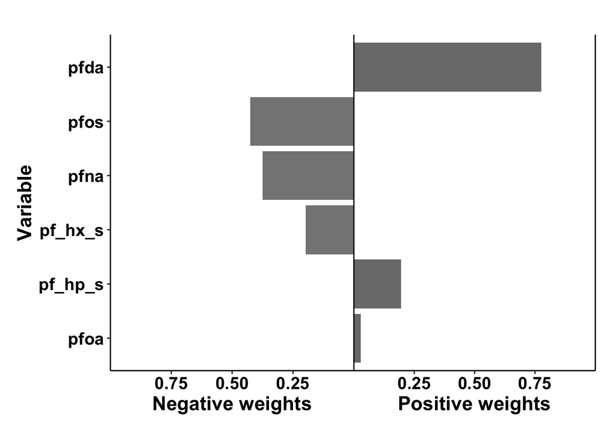

```r
## Step3. View Models --------------

### weighted plot----

plot(qgcomp_output, cex = 1)
```

```r
### saving plot-----
# png(fs::path(dir_figure,
#              "3_weighted_plot_gcomp_nafld.png"),
#     width = 4000, height = 2000, res = 350)
# plot(qgcomp_output)
# dev.off()
```

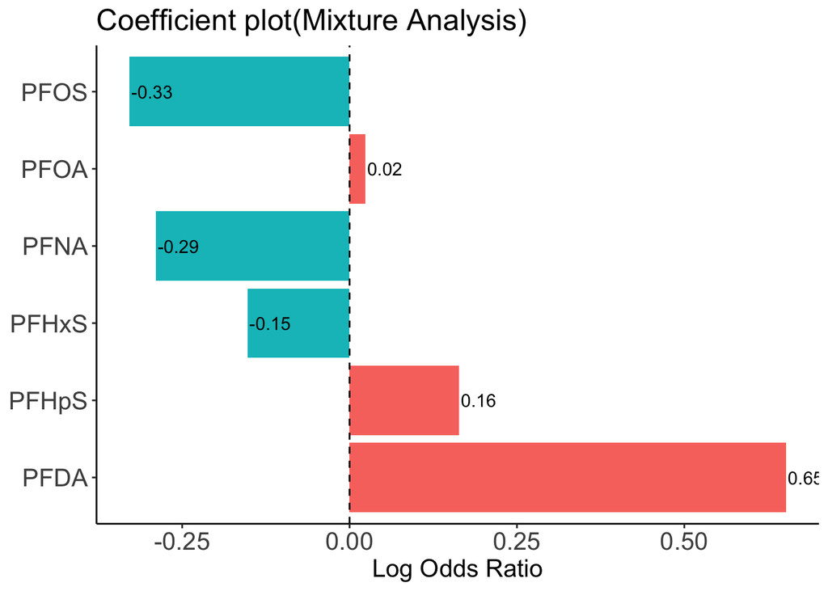

```r
### coefficient plot----
coef <- data.frame(qgcomp_output$fit$coefficients) %>%
  rownames_to_column("Predictor") %>%
  filter(Predictor %in% plasma_pfas1) %>%
  rename('Log Odds Ratio' = qgcomp_output.fit.coefficients) %>%
  mutate(direction = ifelse(`Log Odds Ratio` > 0, "pos", "neg"),
         direction = factor(direction, levels = c("pos", "neg")))

# change the name of the predictor
coef1 <- coef %>% mutate(Predictor = case_when(
  grepl("pfda", Predictor) ~ "PFDA",
  grepl("pfos", Predictor) ~ "PFOS",
  grepl("pfna", Predictor) ~ "PFNA",
  grepl("pf_hx_s", Predictor) ~"PFHxS",
  grepl("pfoa", Predictor) ~ "PFOA",
  grepl("pf_hp_s", Predictor) ~ "PFHpS"
))

p <- ggplot(coef1,aes(Predictor, `Log Odds Ratio`,
                      fill = direction)) +
  geom_bar(stat = "identity", show.legend = FALSE) +
  ggtitle("Coefficient plot(Mixture Analysis)") +
  coord_flip() +
  geom_hline(yintercept = 0, linetype = 2, color = "black") +
  geom_text(aes(label = round(`Log Odds Ratio`,2)), hjust= -0.05) +
  theme(axis.text = element_text(size = 15),
        text = element_text(size = 15),
        axis.title.y = element_blank(),
        axis.line.x = element_line(color = "black"),
        axis.line.y = element_line(color = "black"),
        panel.background = element_rect(fill="white"),
        strip.background = element_rect(fill = "white")
        )

p
```

```r
### saving coefficient plot----
# ggsave(p,
#        filename = fs::path(dir_figure,
#                            "3_coef_plot_qgcomp.jpeg"),
#        width = 7,
#        height = 4)
```